# 有趣的马尔可夫链: 模拟人口迁移

Harry Zhu  
10/10/2014

- 1.算法简介
- 2.编程过程
- 3.仿真结果

### 算法简介

- 问题描述

近年来城镇化进程很快，东北老工业基地的人口却发展缓慢。 人口变动的原因为：

1. 出生
2. 死亡 （学术上：自然增长=出生-死亡）
3. 迁移 （学术上：机械增长）

其中人口迁移是一个复杂的动态过程

本次讲演重点讨论**迁移**在人口变化中的影响

### 算法简介

- 解决思路

假定只讨论某两个地区之间的人口迁移，且以固定的概率迁移

通过已知的人口数量 和 两个地区之间人口迁移的概率可以求得每次迁移后的结果

然后依次迭代 直到不再迁移 得到最终的迁移结果

### 算法简介

- 符号表示

时间：

`m` → `k` → `n`

状态：

`i` = `m`时刻状态

`j` = `k`时刻状态

### 算法简介

- 头疼的概念
- one-step 状态转移矩阵situation probability 某一步转移概率

\[ {P_{ij}}^{(m,m+1)} = \sum {{P_{ik}}^{(m,l)}{P_{kj}}^{(l,n)}} \]

- 每一次的结果 = 概率 * 上一次的结果

```r
##     口口口      口口口     口
##     口口口   =  口口口  *  口
##     口口口      口口口     口
```

### 算法简介

`i` 转移到 `j`的条件概率矩阵叫作状态转移概率;形如:

```
      地区A 地区B
地区A   0.9   0.2
地区B   0.1   0.8
```

### 算法简介

假设初始状态,形如:

```
      初始状态
地区A     2000
地区B      400
```

### 算法简介

- time interval = `n` - `m` 时间间隔
- homogenious situation 齐次代表 方块矩阵

\[ {P_{ij}}^{(m,n+1)} ={P_{ij}} \]

### * review

时间： `m` → `k` → `n`

状态： `i` = `m`时刻状态, `j` = `k`时刻状态

```r
markov <- function(状态转移矩阵,终止时间,初始状态){
起始时间 <- 1
markov <- 状态转移矩阵 %*% 初始状态
markovChain<-matrix(rep(0,终止时间),2,(终止时间))
markovChain[ ,1]<- 初始状态[ ,1]
for (转移次数 in 起始时间:终止时间) {
    markov <- 状态转移矩阵 %*% markov
    markovChain[1,转移次数]<-markov[1,1]
    markovChain[2,转移次数]<-markov[2,1]
}
 return(markovChain)
}
```

### 仿真过程

- 模拟长春和北京的人口迁移
- 假设长春初始有400万人
- 北京有2000万人
- 状态转移矩阵如下

```r
状态转移矩阵 <- matrix(c(0.99, 0.01, 0.02, 0.98), 2, 2)
终止时间 <- 1000
初始状态 <- matrix(c(2000, 400))
```

### 仿真过程

```r
马尔可夫链 <- markov(状态转移矩阵, 终止时间, 初始状态)
time <- 1:终止时间
Capital_Population <- 马尔可夫链[1, ]
Changchun_Population <-马尔可夫链[2, ]
```

### 首都人口

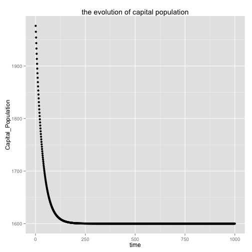

- 解释：显然首都人口将保持在1600万人

### 长春人口

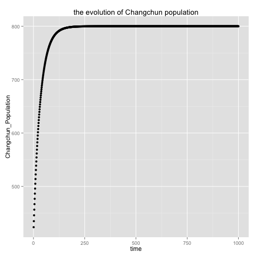

- 解释：显然长春人口将保持在800万人

### 仿真过程

- 修改终止时间

```r
终止时间 <- 10
```

### 首都人口

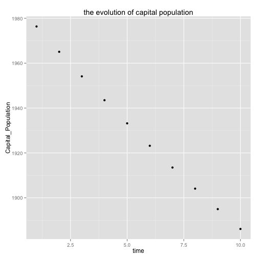

- 解释：显然首都人口将线性下降

### 长春人口

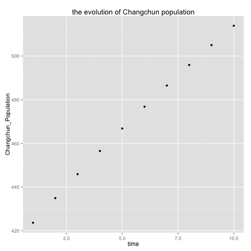

- 解释：显然长春人口将线性增加

### 可以提高的地方

1. 可以进一步通过调查确定长春和北京之间人口迁移的概率
2. 进一步讨论齐次、非齐次等情况